# Lab 5 - Image Restoration

## Goal: Introduction to image restoration

Import the necessary libraries

```python
%matplotlib inline
import numpy as np
import matplotlib.pyplot as plt
from skimage import color,transform,io,util,img_as_float,img_as_ubyte
from skimage import restoration
from skimage.util import random_noise
import cv2
import math
```

Load image and add blurring and noise:

```python
# The function return two images: a blurred image
# and an image after blurring and noise adding
def AddBlurreAndNoise(img, filter_blur,sigma=0.01):
  #N=5
  img_blurre=cv2.filter2D(img,-1 ,filter_blur)
  img_blurre_noise=random_noise(img_blurre,mode='gaussian',var=sigma)#*255.0

  return img_blurre, img_blurre_noise
```

```
Image shape:(251, 201), Image data type:float64
```

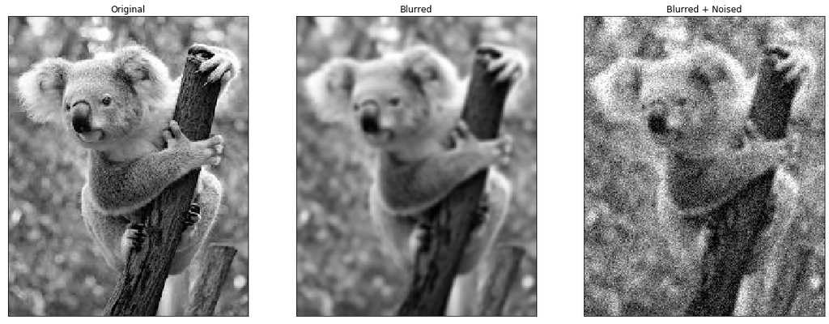

```python
img = color.rgb2gray(io.imread('koala_grey.png'))
img = img_as_float(img)

print ("Image shape:{}, Image data type:{}".format(img.shape,img.dtype))
# Use gaussian kernel for blurring the image
# gaussian kernel is separable function
filter_blur = cv2.getGaussianKernel(ksize=5,sigma=1.85)*cv2.getGaussianKernel(ksize=5,sigma=1.85).T

blurred, noise = AddBlurreAndNoise(img,filter_blur)

plt.figure(figsize=(20,10))
plt.subplot(131),plt.imshow(img, cmap='gray'),plt.title('Original')
plt.xticks([]), plt.yticks([])
plt.subplot(132),plt.imshow(blurred, cmap='gray'),plt.title('Blurred')
plt.xticks([]), plt.yticks([])
plt.subplot(133),plt.imshow(noise, cmap='gray'),plt.title('Blurred + Noised')
plt.xticks([]), plt.yticks([])
plt.show()
```

### Part 1 - Inverse Filter

1. Test the restoration with the Inverse Filter for deblurring and denoising

```python
def InvertFilter(noise_img,filter_blur):
    n,m=noise_img.shape
    DFT_kernel=np.fft.fft2(filter_blur,s=(n,m))
    #in practice we can't divide in 0, so we solve this
    DFT_kernel[DFT_kernel==0]=0.001

    DFT_inv=1/DFT_kernel
    DFT_img=np.fft.fft2(noise_img,s=(n,m))
    DFT_denoise_img=DFT_inv*DFT_img
    denoise_img=np.abs(np.fft.ifft2(DFT_denoise_img))
    return denoise_img
```

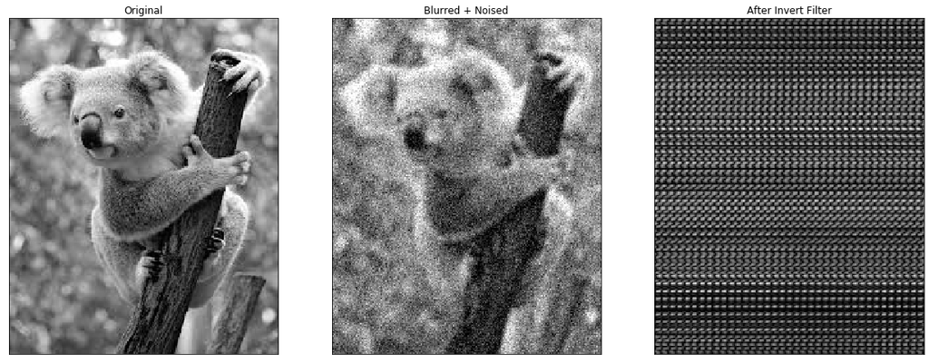

```python
denoise_Invert_img = InvertFilter(noise,filter_blur)

plt.figure(figsize=(20,10))
plt.subplot(131),plt.imshow(img, cmap='gray'),plt.title('Original')
plt.xticks([]), plt.yticks([])
plt.subplot(132),plt.imshow(noise, cmap='gray'),plt.title('Blurred + Noised')
plt.xticks([]), plt.yticks([])
plt.subplot(133),plt.imshow(denoise_Invert_img, cmap='gray'),plt.title('After Invert Filter')
plt.xticks([]), plt.yticks([])
plt.show()
```

1. What is the problem with the Inverse Filter? How can this be solved?

```
The problem with classic simple inverse filter is that when H(u,v)=0 the filter value tends to infinity, and the noise explodes. we avoid division by zero by manually changing zero values of H(u,v) to a small value that are close to zero, but the noise still explodes. The solution is to use one of the other filters.
```

### Part 2 - Pseudo Inverse Filter

1. Test the restoration with the Pseudo Inverse Filter for deblurring and denoising

```python
def PseudoInvertFilter(noise_img, filter_blur, epsilon=0.5):
 M, N = np.shape(noise_img)

 #img_blure_noise_fft = np.fft.fft2(noise_img)
 img_blure_noise_fft = np.fft.fftshift(np.fft.fft2(noise_img, s=(M,N)))
 blur_filter_fft = np.fft.fftshift(np.fft.fft2(filter_blur, s=(M, N)))

 inverse_filter_fft=np.where(blur_filter_fft>epsilon,1.0/blur_filter_fft,0)
 #inverse_filter_fft = 1. / blur_filter_fft
 #inverse_filter_fft[abs(blur_filter_fft) <= epsilon] = 0

 denoise_img_fft = img_blure_noise_fft * inverse_filter_fft
 denoise_img = abs(np.fft.ifft2(denoise_img_fft))
 return denoise_img
```

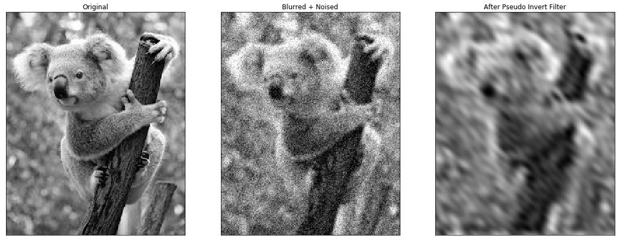

```python
denoise_pseudo_img = PseudoInvertFilter(noise,filter_blur)

plt.figure(figsize=(20,10))
plt.subplot(131),plt.imshow(img, cmap='gray'),plt.title('Original')
plt.xticks([]), plt.yticks([])
plt.subplot(132),plt.imshow(noise, cmap='gray'),plt.title('Blurred + Noised')
plt.xticks([]), plt.yticks([])
plt.subplot(133),plt.imshow(denoise_pseudo_img, cmap='gray'),plt.title('After Pseudo Invert Filter')
plt.xticks([]), plt.yticks([])
plt.show()
```

The Root Mean Square (RMS) error of restoration is defined in the following way: \begin{equation*} RMS = \left( \frac{1}{MN} \sum_{k=0}^{M-1} \sum_{k=0}^{N-1} (\hat{f}(i,j)-f(i,j))^2 \right)^{0.5} \end{equation*}

where $f(i, j)$ is the original image, $\hat{f}(i,j)$ is the restored image and $M \times N$ is the size of both images.

1. Plot the graph of the RMS error (Y axis) versus the parameter $\epsilon$(X axis) and **Show the result of the best restoration.**

(the variance of the noise $\sigma _n ^2$ is fixed to the default value in the supplied program).

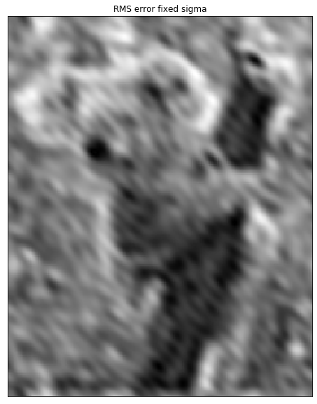

```
best_rms 0.10484706861329463
best epsilon 0.46535353535353535
```

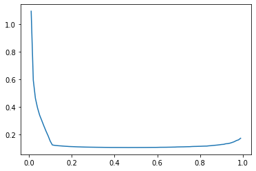

```python
def rms_error(img1,img2):
    rms=0
    m,n = img1.shape
    for i in range (0,m):
        for j in range (0,n):
          rms=rms+(img1[i,j]-img2[i,j])**2
    rms=rms/(m*n)
    rms=math.sqrt(rms)
    return rms

rms_vec=[]
N=100
x=np.linspace(0.01,0.99,100)
for i in range (0,N):
  epsilon=x[i]
  denoise_pseudo_img=PseudoInvertFilter(noise,filter_blur,epsilon)
  denoise_pseudo_img=denoise_pseudo_img#/255
  rms=rms_error(img,denoise_pseudo_img)
  rms_vec.append(rms)
  if (i==0):
    best_restoration_pi=denoise_pseudo_img
    best_rms=rms
    best_epsilon=epsilon
  elif (rms<best_rms):
    best_restoration_pi=denoise_pseudo_img
    best_rms=rms
    best_epsilon=epsilon


plt.figure(figsize=(20,10))
plt.imshow(best_restoration_pi, cmap='gray'),plt.title('RMS error fixed sigma')
plt.xticks([]), plt.yticks([])
plt.show()

plt.plot(x,rms_vec)
print("best_rms {0}\nbest epsilon {1}".format(best_rms,best_epsilon))
```

3.Now fix the parameter $\epsilon = 0.5$. Plot the graph of the Root Mean Square (RMS) error of restoration (Y axis) versus the variance of the noise $\sigma_n^2$ (X axis). **Show the result of the best restoration**

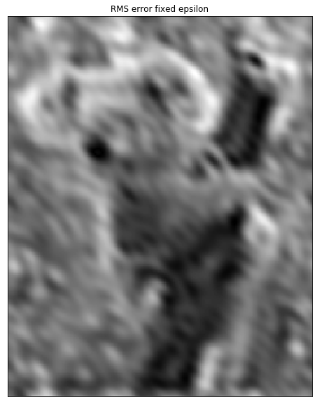

```
best_rms 0.10339759300958928
best sigma 0.001
```

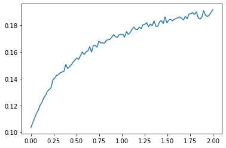

```python
rms_vec=[]
#N=100
x=np.linspace(0.001,2,100)
i=0
for sigma in x:
  remainder,Noise= AddBlurreAndNoise(img,filter_blur,sigma)
  denoise_pi_img=PseudoInvertFilter(Noise,filter_blur,0.5)
  #denoise_pseudo_img=denoise_pseudo_img#/255

  rms=rms_error(img,denoise_pi_img)
  if (i==0):
    best_restoration=denoise_pi_img
    best_rms=rms
    best_sigma=sigma
  elif (rms<best_rms):
     best_restoration=denoise_pi_img
     best_rms=rms
     best_sigma=sigma
  i=i+1
  rms_vec.append(rms)

plt.figure(figsize=(20,10))
plt.imshow(best_restoration, cmap='gray'),plt.title('RMS error fixed epsilon')
plt.xticks([]), plt.yticks([])
plt.show()

plt.plot(x,rms_vec)
print("best_rms {0}\nbest sigma {1}".format(best_rms,best_sigma))
```

3.1. For what maximal value of the variance of noise you still get an acceptable restoration?

[output not shown]

### Part 3 - Wiener Filter

1. Test the restoration with the Wiener Filter for deblurring and denoising

Assume that the variance used in the Wiener filter formula is equal to the variance of the noise $\sigma_n^2$ , and both of them are equal to 0.01 (for image in a range of 0-1) or 0.01 ∗ 255 (for image in a range of 0-255).

```python
def WienerFilter(noise_img,filter_blur,sigma=0.01, alpha=0.095):
    DFT_kernel=np.fft.fft2(filter_blur)
    DFT_wiener_kernel=np.zeros(np.shape(DFT_kernel))
    for i in range(0,len(DFT_kernel)):
        for j in range(0,DFT_kernel.shape[1]):
            DFT_wiener_kernel[i,j]=np.conjugate(DFT_kernel[i,j])/(np.square((np.abs(DFT_kernel[i,j])))+alpha*sigma*(i**2+j**2))

    inv=np.fft.ifft2(DFT_wiener_kernel)
    inv=np.absolute(inv)
    denoise_img=cv2.filter2D(img,-1,inv)
    denoise_img=denoise_img/(np.max(denoise_img))*255.0 #normalizing back to [0,255]
    return denoise_img
```

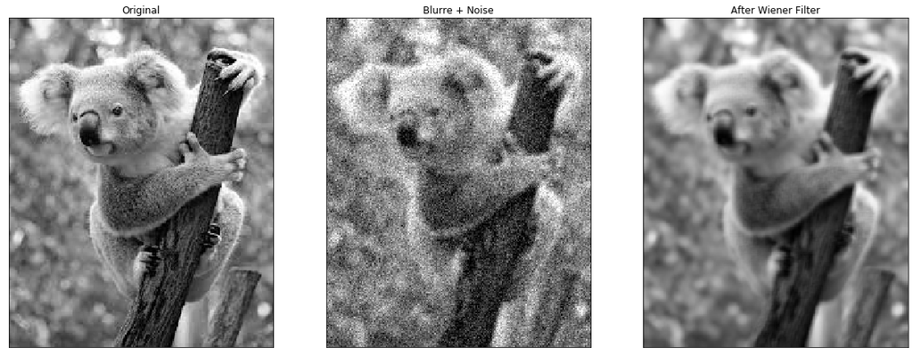

```python
denoise_wiener_img = WienerFilter(noise,filter_blur)

plt.figure(figsize=(20,10))
plt.subplot(131),plt.imshow(img, cmap='gray'),plt.title('Original')
plt.xticks([]), plt.yticks([])
plt.subplot(132),plt.imshow(noise, cmap='gray'),plt.title('Blurre + Noise')
plt.xticks([]), plt.yticks([])
plt.subplot(133),plt.imshow(denoise_wiener_img, cmap='gray'),plt.title('After Wiener Filter')
plt.xticks([]), plt.yticks([])
plt.show()
```

1. Plot the graph of the Root Mean Square (RMS) error of restoration (Y axis) versus the parameter $\sigma_n^2$ (X axis) (change $\sigma_n$ only in the filter, the noise stay the same, also no need to change alpha). **Show the result of the best restoration.**

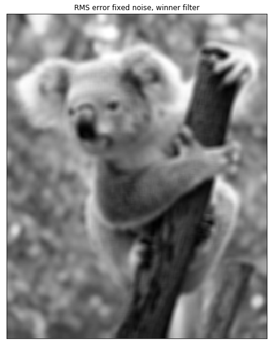

```
best_rms 0.05266299896500571
best wiener filter sigma 0.01
```

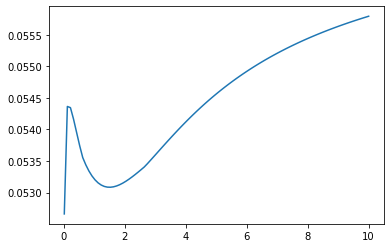

```python
rms_vec=[]
N=100
x=np.linspace(0.01,10,100)
for i in range (0,N):
  sigma=x[i]
  denoise_wiener_img=WienerFilter(noise,filter_blur,sigma)
  denoise_wiener_img=denoise_wiener_img/255
  rms=rms_error(img,denoise_wiener_img)
  if (i==0):
    best_restoration=denoise_wiener_img
    best_rms=rms
    best_sigma=sigma
  elif (rms<best_rms):
     best_restoration=denoise_wiener_img
     best_rms=rms
     best_sigma=sigma

  rms_vec.append(rms)

plt.figure(figsize=(20,10))
plt.imshow(denoise_wiener_img, cmap='gray'),plt.title('RMS error fixed noise, winner filter')
plt.xticks([]), plt.yticks([])
plt.show()

plt.plot(x,rms_vec)
print("best_rms {0}\nbest wiener filter sigma {1}".format(best_rms,best_sigma))
```

### Part 4 - Deep learning (DnCNN)

1. After using a few filters to restoration the image, Lets try with the new approach **Deep learning** and compare the results

For building the neural network we will use the [PyTorch framwork](https://pytorch.org/)

Because of lack of time we aren't going to train the network here. We will use a pretrained model

Few more imports for using pytorch:

```python
import torch
import torch.nn as nn
from torch.autograd import Variable
```

Now we will define the architecture of the neural network.

We will implement the [DnCNN](http://www4.comp.polyu.edu.hk/~cslzhang/paper/DnCNN.pdf) architecture:

[figure not shown]

Has you can see the architecture is a class that inherit from nn.Module (pytorch module)

```python
class DnCNN(nn.Module):
    def __init__(self, channels, num_of_layers=17):
        super(DnCNN, self).__init__()
        kernel_size = 3
        padding = 1
        features = 64
        layers = []
        # first layer: conv2d -> Relu (for activation) :
        layers.append(nn.Conv2d(in_channels=channels, out_channels=features, kernel_size=kernel_size, padding=padding, bias=False))
        layers.append(nn.ReLU(inplace=True))
        # then lets defined all the other hidden layer as: conv2d -> BatchNorm -> Relu
        for _ in range(num_of_layers-2):
            layers.append(nn.Conv2d(in_channels=features, out_channels=features, kernel_size=kernel_size, padding=padding, bias=False))
            layers.append(nn.BatchNorm2d(features))
            layers.append(nn.ReLU(inplace=True))
        # and at the end: need to get back the image so conv2d with out_channels as in the original image:
        layers.append(nn.Conv2d(in_channels=features, out_channels=channels, kernel_size=kernel_size, padding=padding, bias=False))
        # insert all the layers in to Sequential that will pass the data in order
        self.dncnn = nn.Sequential(*layers)

    def forward(self, x):
        # defined the forward pass of our network
        out = self.dncnn(x)
        return out
```

lets pay attention that we don't need to defined the back propagation as the the Pytorch framework will do it for us.

After build the network architecture we need to load the pretrained model and insert the noisy image to it:

```python
def DnCNN_network(noise_img, num_of_layers=17, model_path='net.pth'):

    print('Loading model ...')
    # defined the network, use the class we create above
    net = DnCNN(channels=1, num_of_layers=num_of_layers)
    traind_model = nn.DataParallel(net)
    # load pretrain model
    pretraind = torch.load(model_path)
    # get the state of the model (weights + baises ...)
    traind_model.load_state_dict(pretraind)
    traind_model.double()
    # say to pytorch that we juist want to test the model (not tarin it)
    traind_model.eval()
    print('Loaded\n')
    # Expend dim for using the network:
    noise_img = np.expand_dims(noise_img, 0) # batch dim
    noise_img = np.expand_dims(noise_img, 1) # channels dim
    # cast to tensor variable
    noise_img = torch.DoubleTensor(noise_img)
    INoisy = Variable(noise_img)

    with torch.no_grad(): # this can save much memory
        print("Inserting the noisy image...\n")
        the_noise_that_we_learned = traind_model(INoisy)
        plt.imshow(the_noise_that_we_learned.cpu().squeeze(), cmap='gray'),plt.title('The noise that the network predict')
        plt.show()
        Out = torch.clamp(INoisy.cpu() - the_noise_that_we_learned.cpu(), 0., 1.)
    return Out.squeeze()
```

Explain the following line in the code. Why do we need this line?

```
Out = torch.clamp(INoisy.cpu() - the_noise_that_we_learned.cpu(), 0., 1.)
```

```
To be left out only with values between 0 to 1 in the difference vector Inoisy-learned_noise. i.e. we take out the noise from theoriginal image after the network recognizes the noise only.
```

Now lets use the neural network and show the results:

```
Loading model ...
Loaded

Inserting the noisy image...
```

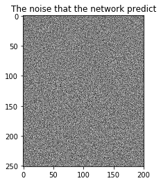

```
rms= 0.05579286719859881
```

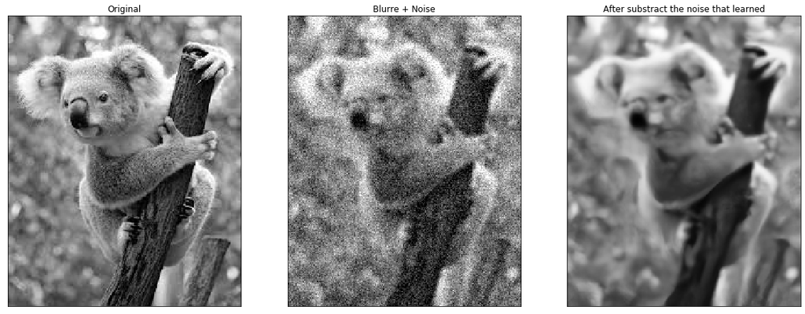

```python
denoise_dncnn_img = DnCNN_network(noise)

rms=rms_error(img,denoise_wiener_img)
print('rms=',rms)
plt.figure(figsize=(20,10))
plt.subplot(131),plt.imshow(img, cmap='gray'),plt.title('Original')
plt.xticks([]), plt.yticks([])
plt.subplot(132),plt.imshow(noise, cmap='gray'),plt.title('Blurre + Noise')
plt.xticks([]), plt.yticks([])
plt.subplot(133),plt.imshow(denoise_dncnn_img, cmap='gray'),plt.title('After substract the noise that learned')
plt.xticks([]), plt.yticks([])
plt.show()
```

1. Lets compare the results from all the methods that we used in this lab:

   Show the best image after restoration from all the methods (Pseudo Invert Filter, Wiener Filter, DnCNN)

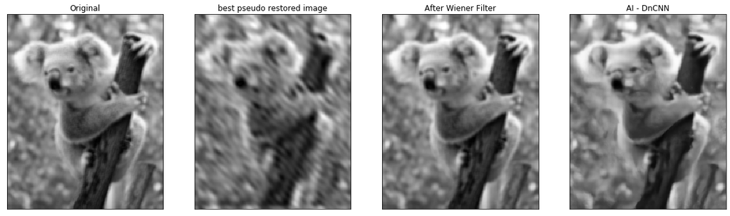

[output not shown]

```python
#Wiener filter has the best restoration. also the lowest RMS error.

plt.figure(figsize=(20,10))
plt.subplot(141),plt.imshow(best_restoration, cmap='gray'),plt.title('Original')
plt.xticks([]), plt.yticks([])
plt.subplot(142),plt.imshow(best_restoration_pi, cmap='gray'),plt.title('best pseudo restored image')
plt.xticks([]), plt.yticks([])
plt.subplot(143),plt.imshow(denoise_wiener_img, cmap='gray'),plt.title('After Wiener Filter')
plt.xticks([]), plt.yticks([])
plt.subplot(144),plt.imshow(denoise_dncnn_img, cmap='gray'),plt.title('AI - DnCNN')
plt.xticks([]), plt.yticks([])
plt.show()
print("best rms: {0}\n for wiener filter".format(best_rms))
```